# Health and Economic Consequences of Severe Weather Events in the US

## Synopsis

This analysis is the second project for the Coursera Data Science Specialization course Reproducible Research. The objective is to use the National Oceanic and Atmospheric Administration’s (NOAA) [Storm Events Database] (https://www.ncdc.noaa.gov/stormevents/) to assess the effects of severe weather events in terms of both health and economic damage.

The analysis considers the health consequences from the perspective of both injuries and fatalies. The economic consequences are represented by combining the estimated value of the damages to property and agriculture (crops).

## Data Processing

The `ggplot2` R package is used to produce the included plots, and the panels are arranged with the `grid` package

```r
library(ggplot2)
library(gridExtra)
```

The first step is to download and read data. Both of these steps can be skipped if the file or object already exists.

```r
if(!exists("stormData")) {
  if(!file.exists("data.csv.bz2")) {
    download.file("https://d396qusza40orc.cloudfront.net/repdata%2Fdata%2FStormData.csv.bz2", "./data.csv.bz2")
  }
  stormData <- read.csv("data.csv.bz2")
}
```

Only the event type (`EVTYPE`), health (`FATALITIES` and `INJURIES`), and damage (`PROPDMG`, `PROPDMGEXP`, `CROPDMG`, `CROPDMGEXP`) are required for this analysis, so select those columns from the full data set.

```r
stormData <- stormData[, c("EVTYPE","FATALITIES","INJURIES","PROPDMG","PROPDMGEXP","CROPDMG","CROPDMGEXP")]
```

### Public Health

Since there is no good metric to compare injuries to fatalities, they are aggregated separately and then each sorted in decreasing order.

```r
fatalities <- aggregate(FATALITIES ~ EVTYPE, data=stormData, FUN=sum)
injuries <- aggregate(INJURIES ~ EVTYPE, data=stormData, FUN=sum)
fatalities <- fatalities[order(fatalities$FATALITIES, decreasing = TRUE),]
injuries <- injuries[order(injuries$INJURIES, decreasing = TRUE),]
```

### Economic Damage

The exponents for the property and crop damage values have been entered using a variety of conventions, so some work needs to be done to extract meaningful value information. Values of H, K, M, and B (either capital or lowercase) have been treated as hundred, thousand, million, and billion, as described in the database documentation. Numerical values are assumed to represent `10^(value)`, and other extraneous symbols (e.g., -, ?, +) are assumed to represent an exponent of zero. First, I define a function to convert between the characters and numeric values.

```r
convExp <- function(symb) {
  symb <- as.character(symb)
  if(symb %in% c("h", "H"))
    return(100)
  if(symb %in% c("k", "K"))
    return(1000)
  if(symb %in% c("m", "M"))
    return(1000000)
  if(symb %in% c("b", "B"))
    return(1000000000)
  if(symb %in% c("", "-", "?", "+"))
    return(1)
  else
    return(10 ** as.numeric(symb))
}
```

Next, apply the function to the `PROPDMGEXP` and `CROPDMGEXP` columns to create multipliers. These values are then multiplied by the `PROPDMG` and `CROPDMG` columns to produce the numerical value for each damage type. They are also added together to produce a total value of damage.

```r
stormData$PropDmgMult <- sapply(stormData$PROPDMGEXP, convExp)
stormData$CropDmgMult <- sapply(stormData$CROPDMGEXP, convExp)
stormData$PropDmgVal <- stormData$PROPDMG * stormData$PropDmgMult
stormData$CropDmgVal <- stormData$CROPDMG * stormData$CropDmgMult
stormData$TotalDmgVal <- stormData$PropDmgVal + stormData$CropDmgVal
```

Finally, each of the damage lists are aggregated by `EVTYPE` sorted in decreasing order.

```r
propDmg <- aggregate(PropDmgVal ~ EVTYPE, data=stormData, FUN=sum)
cropDmg <- aggregate(CropDmgVal ~ EVTYPE, data=stormData, FUN=sum)
totalDmg <- aggregate(TotalDmgVal ~ EVTYPE, data=stormData, FUN=sum)

propDmg <- propDmg[order(propDmg$PropDmgVal, decreasing = TRUE),]
cropDmg <- cropDmg[order(cropDmg$CropDmgVal, decreasing = TRUE),]
totalDmg <- totalDmg[order(totalDmg$TotalDmgVal, decreasing = TRUE),]
```

## Results

### Public Health

The top 10 causes of injuries and fatalities are listed below. The most common cause for both is tornados, followed by thunderstorm winds for injuries and excessive heat for fatalities. Noting similar `EVTYPE` value names, such as `HEAT` and `EXCESSIVE HEAT`, it is likely that some further combination of categories should be undertaken. This has been omitted for the current analysis, however.

```r
head(injuries, 10)
```

```
##                EVTYPE INJURIES
## 834           TORNADO    91346
## 856         TSTM WIND     6957
## 170             FLOOD     6789
## 130    EXCESSIVE HEAT     6525
## 464         LIGHTNING     5230
## 275              HEAT     2100
## 427         ICE STORM     1975
## 153       FLASH FLOOD     1777
## 760 THUNDERSTORM WIND     1488
## 244              HAIL     1361
```

```r
head(fatalities, 10)
```

```
##             EVTYPE FATALITIES
## 834        TORNADO       5633
## 130 EXCESSIVE HEAT       1903
## 153    FLASH FLOOD        978
## 275           HEAT        937
## 464      LIGHTNING        816
## 856      TSTM WIND        504
## 170          FLOOD        470
## 585    RIP CURRENT        368
## 359      HIGH WIND        248
## 19       AVALANCHE        224
```

A plot showing the top 10 causes of each further illustrates the relative harm caused by these events.

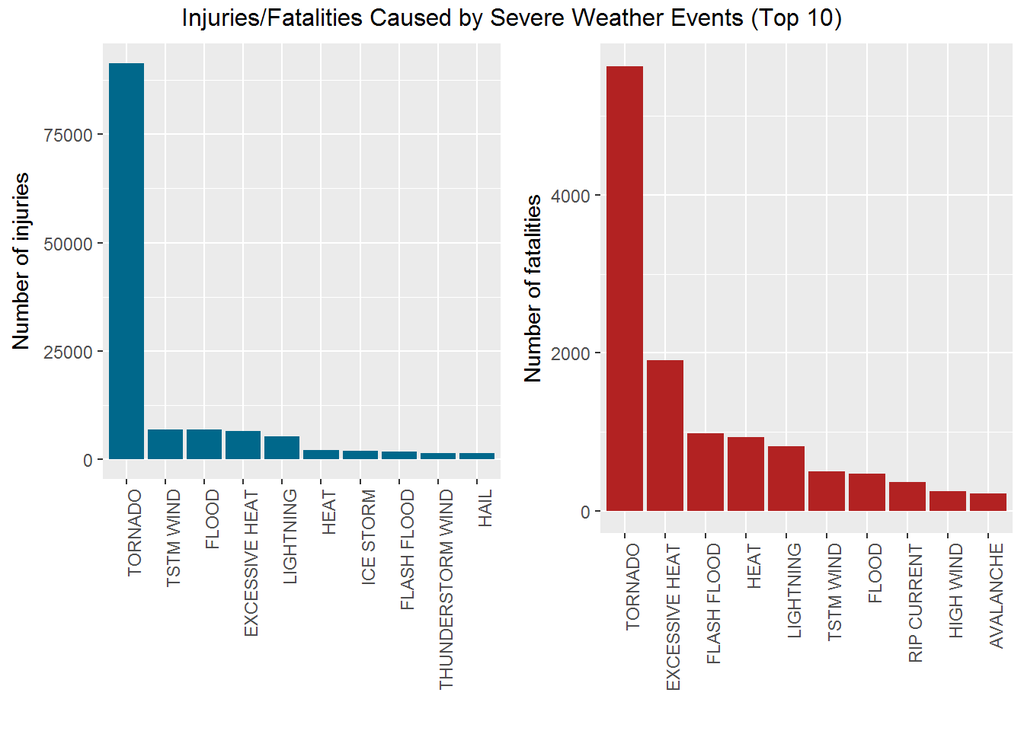

```r
hp1 <- ggplot(head(injuries, 10), aes(x=reorder(EVTYPE, -INJURIES), y=INJURIES))
hp1 <- hp1 + geom_bar(fill = "deepskyblue4", stat = "identity") + theme(axis.text.x = element_text(angle = 90, hjust = 1)) + ylab("Number of injuries") + xlab("")
hp2 <- ggplot(head(fatalities, 10), aes(x=reorder(EVTYPE, -FATALITIES), y=FATALITIES))
hp2 <- hp2 + geom_bar(fill = "firebrick", stat = "identity") + theme(axis.text.x = element_text(angle = 90, hjust = 1)) + ylab("Number of fatalities") + xlab("")
grid.arrange(hp1, hp2, ncol=2, top="Injuries/Fatalities Caused by Severe Weather Events (Top 10)")
```

### Economic Damage

We can likewise examine the top causes of property, crop damage, and total damage

```r
head(propDmg, 10)
```

```
##                EVTYPE   PropDmgVal
## 170             FLOOD 144657709807
## 411 HURRICANE/TYPHOON  69305840000
## 834           TORNADO  56947380677
## 670       STORM SURGE  43323536000
## 153       FLASH FLOOD  16822673979
## 244              HAIL  15735267513
## 402         HURRICANE  11868319010
## 848    TROPICAL STORM   7703890550
## 972      WINTER STORM   6688497251
## 359         HIGH WIND   5270046295
```

```r
head(cropDmg, 10)
```

```
##                EVTYPE  CropDmgVal
## 95            DROUGHT 13972566000
## 170             FLOOD  5661968450
## 590       RIVER FLOOD  5029459000
## 427         ICE STORM  5022113500
## 244              HAIL  3025954473
## 402         HURRICANE  2741910000
## 411 HURRICANE/TYPHOON  2607872800
## 153       FLASH FLOOD  1421317100
## 140      EXTREME COLD  1292973000
## 212      FROST/FREEZE  1094086000
```

```r
head(totalDmg, 10)
```

```
##                EVTYPE  TotalDmgVal
## 170             FLOOD 150319678257
## 411 HURRICANE/TYPHOON  71913712800
## 834           TORNADO  57362333947
## 670       STORM SURGE  43323541000
## 244              HAIL  18761221986
## 153       FLASH FLOOD  18243991079
## 95            DROUGHT  15018672000
## 402         HURRICANE  14610229010
## 590       RIVER FLOOD  10148404500
## 427         ICE STORM   8967041360
```

Because the highest propery damage values are approximately an order of magnitude higher than the highest crop damages, property damage is the dominant contributor to economic damages. However, the presence of unique events such as drought and extreme cold in the crop damage list makes it significant to separate the two categories.

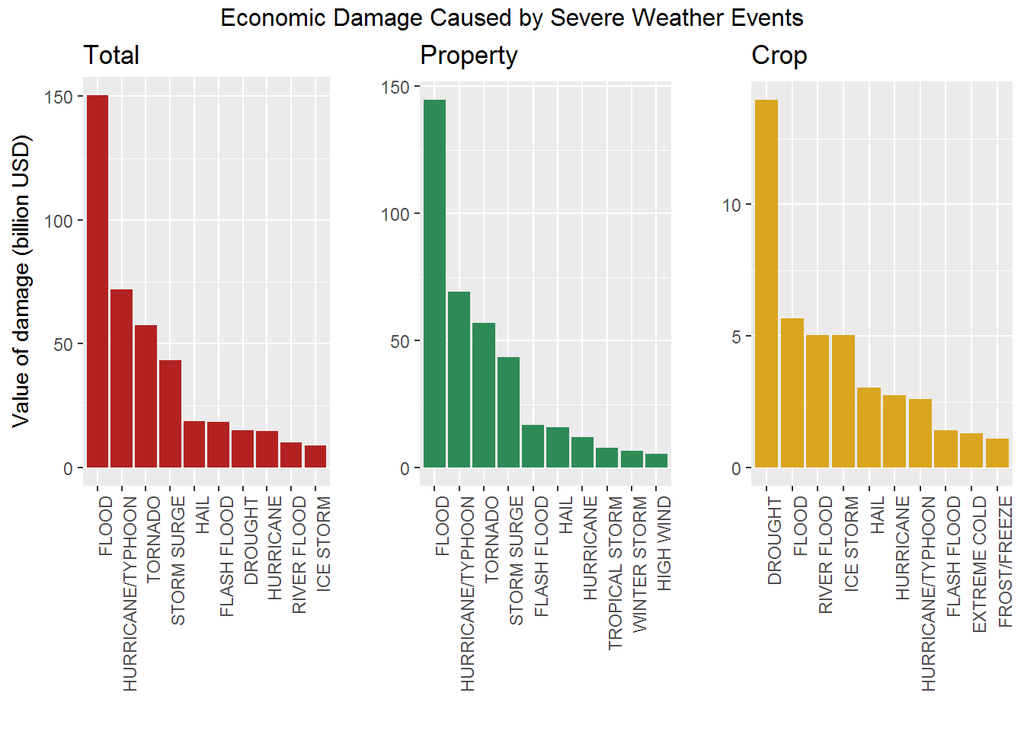

```r
ep1 <- ggplot(head(totalDmg, 10), aes(x=reorder(EVTYPE, -TotalDmgVal), y=TotalDmgVal/1e9))
ep1 <- ep1 + geom_bar(fill = "firebrick", stat = "identity") + theme(axis.text.x = element_text(angle = 90, hjust = 1)) + ylab("Value of damage (billion USD)") + xlab("") + ggtitle("Total")
ep2 <- ggplot(head(propDmg, 10), aes(x=reorder(EVTYPE, -PropDmgVal), y=PropDmgVal/1e9))
ep2 <- ep2 + geom_bar(fill = "seagreen", stat = "identity") + theme(axis.text.x = element_text(angle = 90, hjust = 1)) + ylab("") + xlab("") + ggtitle("Property")
ep3 <- ggplot(head(cropDmg, 10), aes(x=reorder(EVTYPE, -CropDmgVal), y=CropDmgVal/1e9))
ep3 <- ep3 + geom_bar(fill = "goldenrod", stat = "identity") + theme(axis.text.x = element_text(angle = 90, hjust = 1)) + ylab("") + xlab("") + ggtitle("Crop")

grid.arrange(ep1, ep2, ep3, ncol=3, top="Economic Damage Caused by Severe Weather Events")
```